# Quantitative Proteomics Analysis

Your Name

2026-08-12

# Overview

## Aim

The main objectives are to:

1. Import and preprocess quantitative proteomics data.
2. Identify and assess quantitative protein abundance measurements.
3. Evaluate missing values and sample quality.
4. Explore sample relationships using correlation analysis and PCA.
5. Identify differentially abundant proteins using `limma`.
6. Visualize differential protein abundance using volcano plots.
7. Compare significant protein sets across multiple time points.

The analysis focuses on a time-course experiment containing control and treatment conditions measured at 30 minutes, 1 hour, 2 hours, and 4 hours.

# 1. Required R packages

The following packages are used for data manipulation, statistical analysis, quality control, and visualization.

```r
knitr::opts_chunk$set(
  echo = TRUE,
  warning = FALSE,
  message = FALSE
)

library(dplyr)
library(ggplot2)
library(tidyr)
library(tidyverse)

library(fgsea)
library(corrplot)
library(naniar)

library(EnhancedVolcano)
library(pheatmap)

library(DEqMS)
library(limma)

library(factoextra)
library(FactoMineR)
library(ggpubr)
library(RColorBrewer)
library(PCAtools)

library(ggVennDiagram)
library(reshape2)
```

# 2. Import the quantitative proteomics data

Protein table is an output of Proteome Discoverer

```r
data <- read.delim(
  "20231221_MK_Volta_MVL_FAIMS_2CV_Easy15_140min_1785_DDA_500ng_protein.txt",
  sep = "\t",
  header = TRUE,
  check.names = FALSE
)

colnames(data)
```

```
##   [1] "Checked"
##   [2] "old locus tag"
##   [3] "new locus tag"
##   [4] "Protein FDR Confidence: Combined"
##   [5] "Master"
##   [6] "Accession"
##   [7] "Description"
##   [8] "Exp. q-value: Combined"
##   [9] "Sum PEP Score"
##  [10] "Coverage [%]"
##  [11] "# Peptides"
##  [12] "# PSMs"
##  [13] "# Unique Peptides"
##  [14] "# AAs"
##  [15] "MW [kDa]"
```

[output cut: 95 more lines]

The dataset contains protein identifiers, quantitative abundance measurements, and additional information generated during the proteomics workflow.

The column names are inspected to identify the quantitative measurements and verify the structure of the imported dataset.

# 3. Identify quantitative protein measurements

The quantitative abundance columns are identified based on the presence of “Normalized” in their names. The protein abundances normalized by Proteome Discoverer. However, unnormalized abundances can be imported and normalized usign a wished method.

```r
find_quan <- function(df) {

  quan_columns <- character()

  for (cname in colnames(df)) {

    if (grepl("Normalized", cname)) {
      quan_columns <- c(quan_columns, cname)
    }

  }

  return(quan_columns)
}

quan2_columns <- find_quan(data)

quan2_columns
```

```
##  [1] "Abundances (Normalized): F1: Sample, 1"
##  [2] "Abundances (Normalized): F10: Sample, 10"
##  [3] "Abundances (Normalized): F11: Sample, 11"
##  [4] "Abundances (Normalized): F12: Sample, 12"
##  [5] "Abundances (Normalized): F13: Sample, 13"
##  [6] "Abundances (Normalized): F14: Sample, 14"
##  [7] "Abundances (Normalized): F15: Sample, 15"
##  [8] "Abundances (Normalized): F16: Sample, 16"
##  [9] "Abundances (Normalized): F17: Sample, 17"
## [10] "Abundances (Normalized): F18: Sample, 18"
## [11] "Abundances (Normalized): F19: Sample, 19"
## [12] "Abundances (Normalized): F2: Sample, 2"
## [13] "Abundances (Normalized): F20: Sample, 20"
## [14] "Abundances (Normalized): F3: Sample, 3"
## [15] "Abundances (Normalized): F4: Sample, 4"
## [16] "Abundances (Normalized): F5: Sample, 5"
## [17] "Abundances (Normalized): F6: Sample, 6"
## [18] "Abundances (Normalized): F7: Sample, 7"
## [19] "Abundances (Normalized): F8: Sample, 8"
## [20] "Abundances (Normalized): F9: Sample, 9"
```

Only the protein accession and quantitative abundance measurements are retained for downstream analysis.

```r
dfWide <- data %>%
  subset(
    select = c("Accession", quan2_columns)
  )
```

The resulting matrix contains proteins as rows and samples as columns.

# 4. Log2 transformation

Protein abundance measurements are often highly skewed and may span several orders of magnitude. A log2 transformation is therefore applied to make the abundance distributions more suitable for statistical modelling.

```r
rownames(dfWide) <- dfWide$Accession

dfWide$Accession <- NULL

dfWide <- log2(dfWide)

colnames(dfWide)
```

```
##  [1] "Abundances (Normalized): F1: Sample, 1"
##  [2] "Abundances (Normalized): F10: Sample, 10"
##  [3] "Abundances (Normalized): F11: Sample, 11"
##  [4] "Abundances (Normalized): F12: Sample, 12"
##  [5] "Abundances (Normalized): F13: Sample, 13"
##  [6] "Abundances (Normalized): F14: Sample, 14"
##  [7] "Abundances (Normalized): F15: Sample, 15"
##  [8] "Abundances (Normalized): F16: Sample, 16"
##  [9] "Abundances (Normalized): F17: Sample, 17"
## [10] "Abundances (Normalized): F18: Sample, 18"
## [11] "Abundances (Normalized): F19: Sample, 19"
## [12] "Abundances (Normalized): F2: Sample, 2"
## [13] "Abundances (Normalized): F20: Sample, 20"
## [14] "Abundances (Normalized): F3: Sample, 3"
## [15] "Abundances (Normalized): F4: Sample, 4"
## [16] "Abundances (Normalized): F5: Sample, 5"
## [17] "Abundances (Normalized): F6: Sample, 6"
## [18] "Abundances (Normalized): F7: Sample, 7"
## [19] "Abundances (Normalized): F8: Sample, 8"
## [20] "Abundances (Normalized): F9: Sample, 9"
```

The protein accession is retained as the row identifier throughout the analysis.

The log2 scale also provides an intuitive interpretation of fold changes. A log2 fold change of 1 corresponds to a 2-fold increase, while a log2 fold change of -1 corresponds to a 2-fold decrease.

# 5. Matching sample identifiers

The sample names in the quantitative matrix are matched to the identifiers defined in the experimental design.

```r
ED <- read.delim(
  "experimental_design_normalized.txt"
)

ED
```

```
##                                    SampleID   Name Group
## 1    Abundances (Normalized): F1: Sample, 1   ctr1   ctr
## 2    Abundances (Normalized): F2: Sample, 2   ctr2   ctr
## 3    Abundances (Normalized): F3: Sample, 3   ctr3   ctr
## 4    Abundances (Normalized): F4: Sample, 4   ctr4   ctr
## 5    Abundances (Normalized): F5: Sample, 5 T30m-1  T30m
## 6    Abundances (Normalized): F6: Sample, 6 T30m-2  T30m
## 7    Abundances (Normalized): F7: Sample, 7 T30m-3  T30m
## 8    Abundances (Normalized): F8: Sample, 8 T30m-4  T30m
## 9    Abundances (Normalized): F9: Sample, 9 T1h1-1   T1h
## 10 Abundances (Normalized): F10: Sample, 10 T1h1-2   T1h
## 11 Abundances (Normalized): F11: Sample, 11 T1h1-3   T1h
## 12 Abundances (Normalized): F12: Sample, 12 T1h1-4   T1h
## 13 Abundances (Normalized): F13: Sample, 13  T2h-1   T2h
## 14 Abundances (Normalized): F14: Sample, 14  T2h-2   T2h
## 15 Abundances (Normalized): F15: Sample, 15  T2h-3   T2h
## 16 Abundances (Normalized): F16: Sample, 16  T2h-4   T2h
## 17 Abundances (Normalized): F17: Sample, 17  T4h-1   T4h
## 18 Abundances (Normalized): F18: Sample, 18  T4h-2   T4h
## 19 Abundances (Normalized): F19: Sample, 19  T4h-3   T4h
## 20 Abundances (Normalized): F20: Sample, 20  T4h-4   T4h
```

```r
name_mapping <- setNames(
  ED$Name,
  ED$SampleID
)


dfWide <- dfWide %>%
  rename_with(
    ~ name_mapping[.],
    .cols = names(dfWide)
  )

#the quantitative matrix is reordered to match the order specified in the experimental design.
order_vector <- ED$Name

dfWide <- dfWide %>%
  select(all_of(order_vector))

head(dfWide)
```

```
##                ctr1     ctr2     ctr3     ctr4   T30m-1   T30m-2   T30m-3
## Q2FJ97     30.27595 30.01635 30.22996 30.33948 30.83787 30.86356 30.71990
## Q2FJ98     29.67236 29.61221 29.64521 29.73420 30.35178 30.28555 30.26289
## Q2FJ93     31.30144 31.19640 31.34309 31.36361 31.47209 31.48401 31.34026
## A0A0H2XJH7 31.37788 30.82579 31.39782 31.38456 31.28982 31.14940 30.83951
## Q2FK44     27.20587 27.13924 27.25109 27.32062 27.50381 27.64955 27.79304
## Q2FI09     30.20567 30.23942 30.22830 30.23933 29.71586 29.70787 29.70404
##              T30m-4   T1h1-1   T1h1-2   T1h1-3   T1h1-4    T2h-1    T2h-2
## Q2FJ97     30.67465 30.37958 30.45251 30.49845 30.53374 30.47839 30.59435
## Q2FJ98     30.18591 30.09334 30.21908 30.10753 30.19119 30.13795 30.27222
## Q2FJ93     31.29314 31.12394 31.13958 31.20937 31.24645 30.95953 30.88127
## A0A0H2XJH7 30.71635 30.98737 31.29405 31.42708 31.69409 31.65866 31.37016
## Q2FK44     27.79861 29.83337 29.77345 29.83127 29.83008 30.03435 29.95058
## Q2FI09     29.67474 30.02911 29.96942 30.08710 30.05803 29.85954 29.78468
##               T2h-3    T2h-4    T4h-1    T4h-2    T4h-3    T4h-4
## Q2FJ97     30.48404 30.56503 30.28479 30.44943 30.34179 30.22072
## Q2FJ98     30.11118 30.26836 29.95691 29.80491 29.78903 29.90082
## Q2FJ93     30.91603 30.91943 30.93516 30.99895 30.98688 30.91121
## A0A0H2XJH7 31.49608 31.26381 31.28652 31.40334 30.64783 31.35480
## Q2FK44     30.00860 29.98608 29.79528 29.83337 29.77162 29.69000
## Q2FI09     29.84050 29.81161 29.76799 29.85000 29.80303 29.72268
```

```r
colnames(dfWide)
```

```
##  [1] "ctr1"   "ctr2"   "ctr3"   "ctr4"   "T30m-1" "T30m-2" "T30m-3" "T30m-4"
##  [9] "T1h1-1" "T1h1-2" "T1h1-3" "T1h1-4" "T2h-1"  "T2h-2"  "T2h-3"  "T2h-4"
## [17] "T4h-1"  "T4h-2"  "T4h-3"  "T4h-4"
```

# 6. Assessment of missing values

Identfied proteins and missing measurements are quantified for every sample.

```r
bar1 <- colSums(!is.na(dfWide))

bar2 <- colSums(is.na(dfWide))

df1 <- data.frame(t(bar1))
df2 <- data.frame(t(bar2))

pnum1 <- rbind(
  df1,
  df2
)

rownames(pnum1) <- c(
  "Number of proteins",
  "Number of NAs"
)

pnum2 <- as.matrix(pnum1)

pnum2
```

```
##                    ctr1 ctr2 ctr3 ctr4 T30m.1 T30m.2 T30m.3 T30m.4 T1h1.1
## Number of proteins 1761 1739 1766 1766   1753   1756   1727   1726   1723
## Number of NAs        72   94   67   67     80     77    106    107    110
##                    T1h1.2 T1h1.3 T1h1.4 T2h.1 T2h.2 T2h.3 T2h.4 T4h.1 T4h.2
## Number of proteins   1733   1748   1739  1724  1733  1724  1731  1739  1737
## Number of NAs         100     85     94   109   100   109   102    94    96
##                    T4h.3 T4h.4
## Number of proteins  1738  1740
## Number of NAs         95    93
```

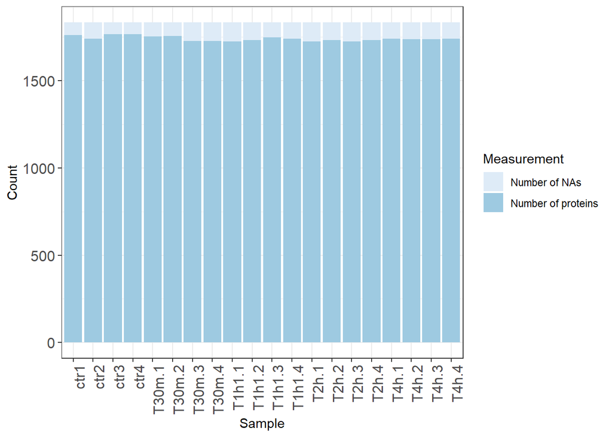

```r
data_long <- melt(
  pnum2
)

p1 <- ggplot(
  data_long,
  aes(
    x = Var2,
    y = value,
    fill = forcats::fct_rev(Var1)
  )
) +
  geom_bar(
    position = "stack",
    stat = "identity"
  ) +
  xlab("Sample") +
  ylab("Count") +
  labs(
    fill = "Measurement"
  ) +
  scale_fill_brewer(
    palette = 1
  ) +
  theme_bw() +
  theme(
    axis.text.x = element_text(
      angle = 90,
      hjust = 1,
      size = 12
    ),
    axis.text.y = element_text(
      size = 12
    )
  )

p1
```

# 7. Missing-value filtering

In this dataset, the observed level of missingness was considered sufficiently low to remove proteins containing missing observations rather than performing imputation.

```r
dfWide <- na.omit(dfWide)
```

# 8. Sample correlation analysis

Pairwise Pearson correlations are calculated between samples using their protein abundance profiles.

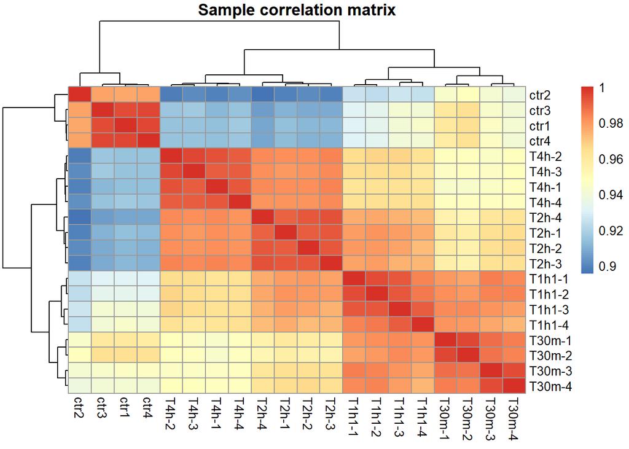

```r
cm <- dfWide

cm <- cor(
  cm,
  method = "pearson"
)

pheatmap(
  cm,
  main = "Sample correlation matrix"
)
```

# 9. Principal Component Analysis

Principal Component Analysis (PCA) is used to investigate the major sources of variation within the proteomic dataset.

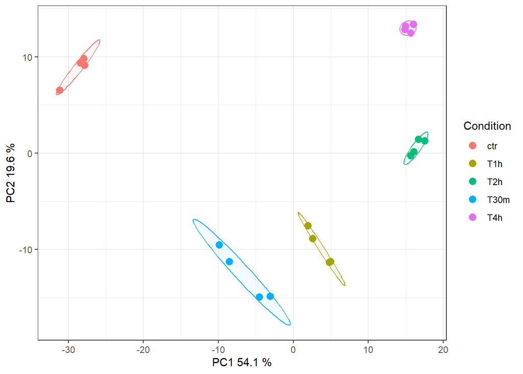

```r
condition <- ED$Group

sample <- ED$Name

pca_data <- prcomp(
  t(dfWide)
)

pca_data_perc <- round(
  100 *
    pca_data$sdev^2 /
    sum(pca_data$sdev^2),
  1
)

df_pca_data <- data.frame(
  PC1 = pca_data$x[, 1],
  PC2 = pca_data$x[, 2],
  sample = colnames(dfWide),
  condition = condition
)


p3 <- ggplot(
  df_pca_data,
  aes(
    PC1,
    PC2,
    color = condition
  )
) +
  geom_point(
    size = 3
  ) +
  theme_bw() +
  stat_ellipse(
    geom = "polygon",
    aes(fill = condition),
    alpha = 0.05,
    show.legend = FALSE,
    level = 0.80
  ) +
  labs(
    x = paste0(
      "PC1 ",
      pca_data_perc[1],
      " %"
    ),
    y = paste0(
      "PC2 ",
      pca_data_perc[2],
      " %"
    ),
    color = "Condition"
  )

p3
```

# 10. Differential protein abundance analysis

Differential protein abundance is assessed using the limma linear modelling framework.

```r
dfD <- dfWide
#Define the design vector
cond=as.factor(ED$Group)

design = model.matrix(~+cond-1)
colnames(design) = gsub("cond","",colnames(design))
design
```

```
##    ctr T1h T2h T30m T4h
## 1    1   0   0    0   0
## 2    1   0   0    0   0
## 3    1   0   0    0   0
## 4    1   0   0    0   0
## 5    0   0   0    1   0
## 6    0   0   0    1   0
## 7    0   0   0    1   0
## 8    0   0   0    1   0
## 9    0   1   0    0   0
## 10   0   1   0    0   0
## 11   0   1   0    0   0
## 12   0   1   0    0   0
## 13   0   0   1    0   0
## 14   0   0   1    0   0
## 15   0   0   1    0   0
## 16   0   0   1    0   0
## 17   0   0   0    0   1
## 18   0   0   0    0   1
## 19   0   0   0    0   1
## 20   0   0   0    0   1
## attr(,"assign")
## [1] 1 1 1 1 1
## attr(,"contrasts")
## attr(,"contrasts")$cond
## [1] "contr.treatment"
```

```r
#Make contrasts
x <- c("T30m-ctr", "T1h-ctr","T2h-ctr", "T4h-ctr", "T1h-T30m", "T2h-T30m","T4h-T30m","T2h-T1h","T4h-T1h","T4h-T2h")
contrast =  makeContrasts(contrasts=x,levels=design)
contrast
```

```
##       Contrasts
## Levels T30m-ctr T1h-ctr T2h-ctr T4h-ctr T1h-T30m T2h-T30m T4h-T30m T2h-T1h
##   ctr        -1      -1      -1      -1        0        0        0       0
##   T1h         0       1       0       0        1        0        0      -1
##   T2h         0       0       1       0        0        1        0       1
##   T30m        1       0       0       0       -1       -1       -1       0
##   T4h         0       0       0       1        0        0        1       0
##       Contrasts
## Levels T4h-T1h T4h-T2h
##   ctr        0       0
##   T1h       -1       0
##   T2h        0      -1
##   T30m       0       0
##   T4h        1       1
```

```r
fit1 <- lmFit(dfD, design)
fit2 <- contrasts.fit(fit1,contrasts = contrast)
fit3 <- eBayes(fit2, trend=TRUE, robust=TRUE)

#How many differentially expressed proteins are there (only taking in account the p value and p value and log2FC)
de1<-summary(decideTests(fit3))
de1
```

```
##        T30m-ctr T1h-ctr T2h-ctr T4h-ctr T1h-T30m T2h-T30m T4h-T30m T2h-T1h
## Down        547     579     701     597      237      500      474     308
## NotSig      759     695     506     563     1179      720      675    1024
## Up          290     322     389     436      180      376      447     264
##        T4h-T1h T4h-T2h
## Down       336     138
## NotSig     875    1207
## Up         385     251
```

```r
de2<-summary(decideTests(fit3, lfc=1))
de2
```

```
##        T30m-ctr T1h-ctr T2h-ctr T4h-ctr T1h-T30m T2h-T30m T4h-T30m T2h-T1h
## Down         43     104     166     140       11       61       90      27
## NotSig     1459    1377    1253    1259     1556     1435     1362    1515
## Up           94     115     177     197       29      100      144      54
##        T4h-T1h T4h-T2h
## Down        51      22
## NotSig    1434    1545
## Up         111      29
```

```r
#Exctract differentially expressed proteins across all time points

degs<-topTable(fit3,lfc=1, n="inf")



#cALCULATE PAIRWISE comparisons
T1<-topTable(fit3, coef=1, n="inf")
T2<-topTable(fit3, coef=2, n="inf")
T3<-topTable(fit3, coef=3, n="inf")
T4<-topTable(fit3, coef=4, n="inf")
```

# 11. Volcano plot: 4 hours versus control

A volcano plot is generated for the 4-hour versus control comparison.

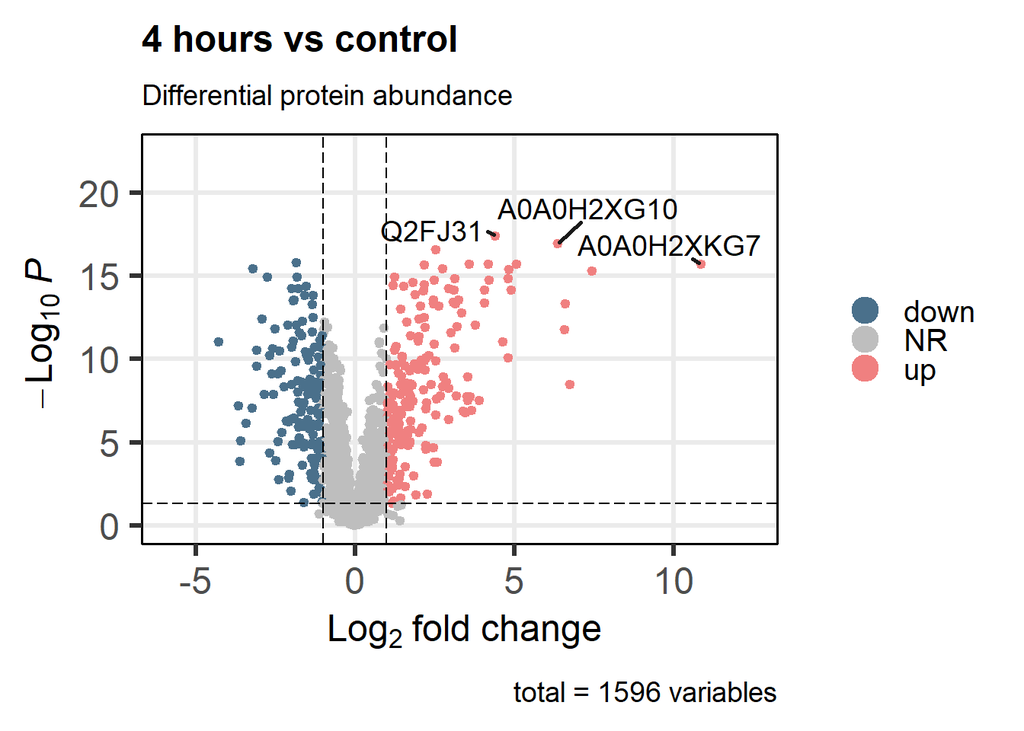

```r
vol <- T4

keyvals <- ifelse(
  vol$logFC < -1 &
    vol$adj.P.Val < 0.05,
  "skyblue4",
  ifelse(
    vol$logFC > 1 &
      vol$adj.P.Val < 0.05,
    "lightcoral",
    "grey"
  )
)

keyvals[is.na(keyvals)] <- "grey"

names(keyvals)[
  keyvals == "lightcoral"
] <- "up"

names(keyvals)[
  keyvals == "grey"
] <- "NR"

names(keyvals)[
  keyvals == "skyblue4"
] <- "down"



v1 <- EnhancedVolcano(
  vol,
  lab = rownames(vol),
  x = "logFC",
  y = "adj.P.Val",
  xlab = bquote(~Log[2]~ "fold change"),
  title = "4 hours vs control",
  pCutoff = 0.05,
  FCcutoff = 1,
  pointSize = 1,
  subtitle = "Differential protein abundance",
  colCustom = keyvals,
  colAlpha = 1,
  legendPosition = "right",
  legendLabSize = 15,
  legendIconSize = 5,
  drawConnectors = TRUE,
  widthConnectors = 1,
  arrowheads = FALSE,
  gridlines.major = TRUE,
  gridlines.minor = FALSE,
  border = "full",
  borderWidth = 0.7
)

v1
```

# 12. How many DEGs are common between different time points (lfc>1)

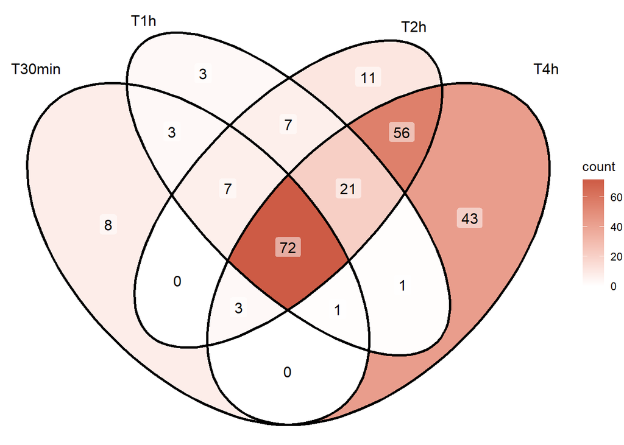

```r
library(ggVennDiagram)
library(ggplot2)


T1_sign <- filter(T1, logFC> (1) & adj.P.Val < 0.05)
T2_sign <- filter(T2, logFC> (1) & adj.P.Val < 0.05)
T3_sign <- filter(T3, logFC>(1)  & adj.P.Val < 0.05)
T4_sign <- filter(T4, logFC>(1) & adj.P.Val < 0.05)



sign<-list(T30min=rownames(T1_sign), T1h=rownames(T2_sign), T2h=rownames(T3_sign), T4h=rownames(T4_sign))

venn <- ggVennDiagram(
  sign,
  label = "count",
  set_color = "black",
  label_color = "black"
) +
  scale_fill_gradient(
    low = "white",
    high = "coral3"
)

venn
```

The Venn diagram summarizes the overlap of significantly upregulated proteins across the time course. The diagram can also be generated for downregulated proteins according to this example:

T1_sign <- filter(T1, logFC< (-1) & adj.P.Val < 0.05)

Proteins shared between multiple time points may represent a persistent response, whereas proteins restricted to individual time points may indicate more of a time-specific regulation.

# 13.Soft clustering to identfy proteins with the same abudnance profile across different time points uzing mfuzz package

```r
# Needed packages

library(dplyr)
library(ggplot2)
library(tidyverse)
library(Mfuzz)
library(RColorBrewer)


#Load required objects and prepare for clustering. The table has to be in a specific format, protein abudances should not be log transformed

dfWide_degs <- dfWide[rownames(dfWide) %in% rownames(degs), , drop = FALSE]

# Apply the un-log transformation to the numeric columns
dfWide_unlog <- dfWide_degs
dfWide_unlog <- as.data.frame(2^dfWide_degs)




#Mfuzz takes an average protein abundance from the group, so you need to average it. For that you need to



dfLong <- dfWide_unlog %>%
  rownames_to_column("Accession") %>%
  pivot_longer(
    cols = -Accession,
    names_to = "Name",
    values_to = "Abundance"
  )

dfLong <- dfLong %>%
  left_join(ED, by = "Name")

dfLong<-dfLong %>% select(-SampleID)


df_Long_average<-dfLong%>%
  group_by(Accession, Group,) %>%
  summarize(mean_value = mean(Abundance, na.rm = TRUE)) %>%
  ungroup()


#Transfer back to the wide format

expr_set <- df_Long_average %>%
  pivot_wider(names_from = Group, values_from = mean_value)


time_values <- c(0, 0.5, 1, 2, 4)
expr_set <- rbind(expr_set, time_values)

desired_order <- c(1,6, 4, 2, 3, 5)

# Rearrange columns in the data frame
expr_set <- expr_set[, c(desired_order)]

write_tsv(expr_set, file="expr_set_degs_test.txt")


expr_set<-table2eset("expr_set_degs_test.txt")

#------------------------------Standardize, this is not normalization

expr_set_s <- standardise(expr_set)



#----------------We would expect that D.min declines slower after reaching an optimal c (see also example of function D.min)
# For fuzzifier m, we would like to choose a value which prevents clustering of random data.
m1 <- mestimate(expr_set_s)
m1
```

```
## [1] 2.14029
```

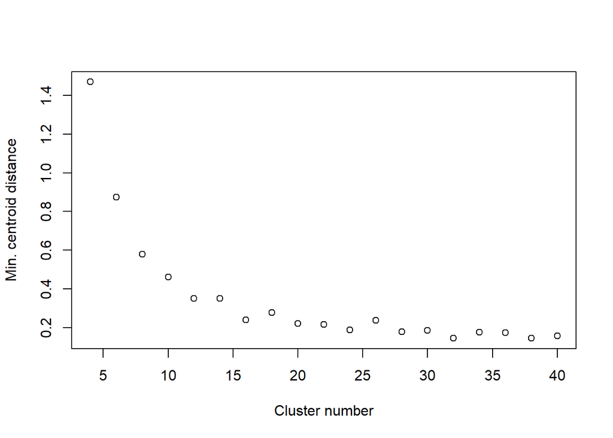

```
##  [1] 1.4703968 0.8735524 0.5798210 0.4604225 0.3511264 0.3508524 0.2384840
##  [8] 0.2779247 0.2209646 0.2156629 0.1875705 0.2359634 0.1775712 0.1842942
## [15] 0.1444901 0.1749953 0.1727098 0.1459503 0.1561629
```

```r
Dmin(expr_set_s,m1,crange=seq(4,40,2),repeats=3,visu=TRUE)
```

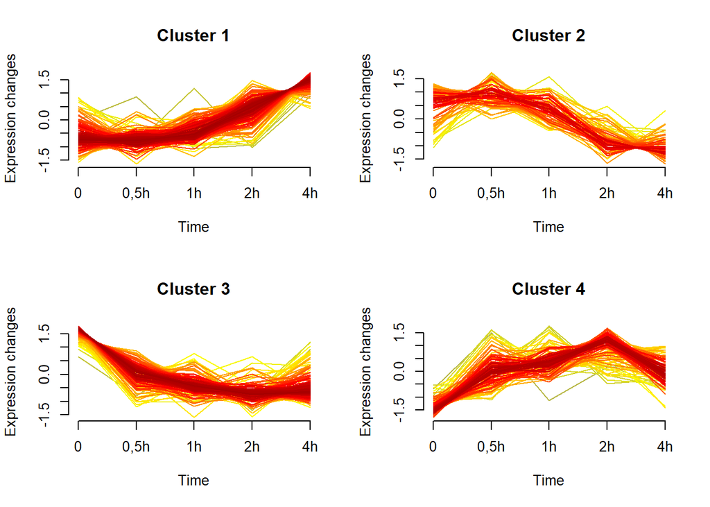

```r
#-------------------Change parameters in mfuzz depending on the results of c and m1


cl <- mfuzz(expr_set_s,c=4,m=2.14)


mplot <- mfuzz.plot2(
  expr_set_s,
  cl = cl,
  mfrow = c(2, 2),
  colo = "fancy",
  time.labels = c("0", "0,5h", "1h", "2h", "4h"),
  x11 = FALSE
)
```